# Working with Factors and Labels

Live Tutorial

# Introduction 😺

In this tutorial, we will explore how to work with **factors** and **labels** in R using two powerful packages: `forcats` and `sjlabelled`. These packages are particularly useful when dealing with categorical variables and labeling datasets to make them easier to interpret.

# Getting Started 😸

Let’s start by loading the required packages and our cleaned **Cat Breeds Dataset**. The dataset contains information on different breeds of cats for adoption, including their age, gender, size and breed name. Kudos to Ma7555 for the original dataset! Retrieved from Kaggle: https://www.kaggle.com/datasets/ma7555/cat-breeds-dataset

```r
# Install necessary packages if not already installed
required_packages <- c("forcats", "sjlabelled", "dplyr", "ggplot2")
new_packages <- required_packages[!(required_packages %in% installed.packages()[, "Package"])]
if(length(new_packages)) install.packages(new_packages)

# Load necessary librarys
library(forcats) # Useful for working with categorical data (factors).
library(sjlabelled) # Helps with labeling data frames and variables.
library(dplyr) # Provides functions for data manipulation.
library(ggplot2) # Used for creating complex and customizable plots.

# Load the data
cat_breeds <- read.csv("data/cat_breeds_cleaned.csv")

# Inspect the structure of the dataset
str(cat_breeds)
```

```
## 'data.frame':    67145 obs. of  4 variables:
##  $ age   : chr  "Adult" "Adult" "Senior" "Baby" ...
##  $ gender: chr  "Female" "Male" "Female" "Female" ...
##  $ size  : chr  "Medium" "Extra Large" "Medium" "Small" ...
##  $ breed : chr  "Abyssinian" "Abyssinian" "Abyssinian" "Abyssinian" ...
```

# Task 1: Explore and Convert Columns to Factors 🐱

Inspect the structure of the `cat_breeds` dataset, find the unique values in each column, and convert the `age`, `size`, `gender`, and `breed` columns into factors. Remember that some factors are ordered!

**🔍 Click for a Hint**

Use `sapply()` and `unique()` to check unique values. Convert the columns using the `factor()` function. Be sure to specify the levels for ordered factors.

**💡 Click to see the Solution**

```r
# Check unique values in each column
sapply(cat_breeds, unique)
```

```
## $age
## [1] "Adult"  "Senior" "Baby"   "Young"
##
## $gender
## [1] "Female"  "Male"    "Unknown"
##
## $size
## [1] "Medium"      "Extra Large" "Small"       "Large"
##
## $breed
##  [1] "Abyssinian"
##  [2] "American Bobtail"
##  [3] "American Curl"
##  [4] "American Shorthair"
##  [5] "American Wirehair"
```

[output cut: 62 more lines]

```r
# Convert columns to factors (with ordered levels where applicable)
cat_breeds$age <- factor(cat_breeds$age, levels = c("Baby", "Young", "Adult", "Senior"), ordered = TRUE)
cat_breeds$size <- factor(cat_breeds$size, levels = c("Small", "Medium", "Large", "Extra Large"), ordered = TRUE)
cat_breeds$gender <- factor(cat_breeds$gender)
cat_breeds$breed <- factor(cat_breeds$breed)

# Check the structure again after conversions
str(cat_breeds)
```

```
## 'data.frame':    67145 obs. of  4 variables:
##  $ age   : Ord.factor w/ 4 levels "Baby"<"Young"<..: 3 3 4 1 2 2 3 3 1 1 ...
##  $ gender: Factor w/ 3 levels "Female","Male",..: 1 2 1 1 1 2 1 2 1 2 ...
##  $ size  : Ord.factor w/ 4 levels "Small"<"Medium"<..: 2 4 2 1 2 2 2 2 1 1 ...
##  $ breed : Factor w/ 67 levels "Abyssinian","American Bobtail",..: 1 1 1 1 1 1 1 1 1 1 ...
```

# Task 2: Factor Manipulation with `forcats` 🐾

Simplify the dataset by keeping only the 10 most frequent cat breeds, and lump the rest together as “Other.”

**🔍 Click for a Hint**

Use the `fct_lump()` function from the `forcats` package to group less frequent categories. In `fct_lump(f, n)` use the parameter n for the number of most frequent levels to keep. All other levels are lumped into “Other”.

**💡 Click to see the Solution**

```r
# Keep the 10 most frequent breeds, lump the rest into "Other"
cat_breeds$breed <- fct_lump(cat_breeds$breed, n = 10)

# Check the structure again to verify the changes
str(cat_breeds$breed)
```

```
##  Factor w/ 11 levels "American Shorthair",..: 11 11 11 11 11 11 11 11 11 11 ...
```

# Task 3: Find the monster breed! 🐾😈

The Monster Breed is the most common breed that has the highest number of Extra Large cats! 🐱💪

What we did for you in the hints: Filter the dataset for cats of size “Extra Large”. Group the data by breed and summarize the number of Extra Large cats for each breed. Visualize the results with the breeds in random order.

Your goal is to: Visualize the result again, but with the breeds ordered by the number of cats to help find the Monster Breed!

**🔍 Click for a Hint**

Use `filter()` and `group_by()` to create the summary, and `fct_reorder()` to reorder the breeds in the plot by the amount of Extra Large cats! In `fct_reorder(f, x)` use parameter f for factor that needs to be reordered and x for numerical vector to reorder f by.

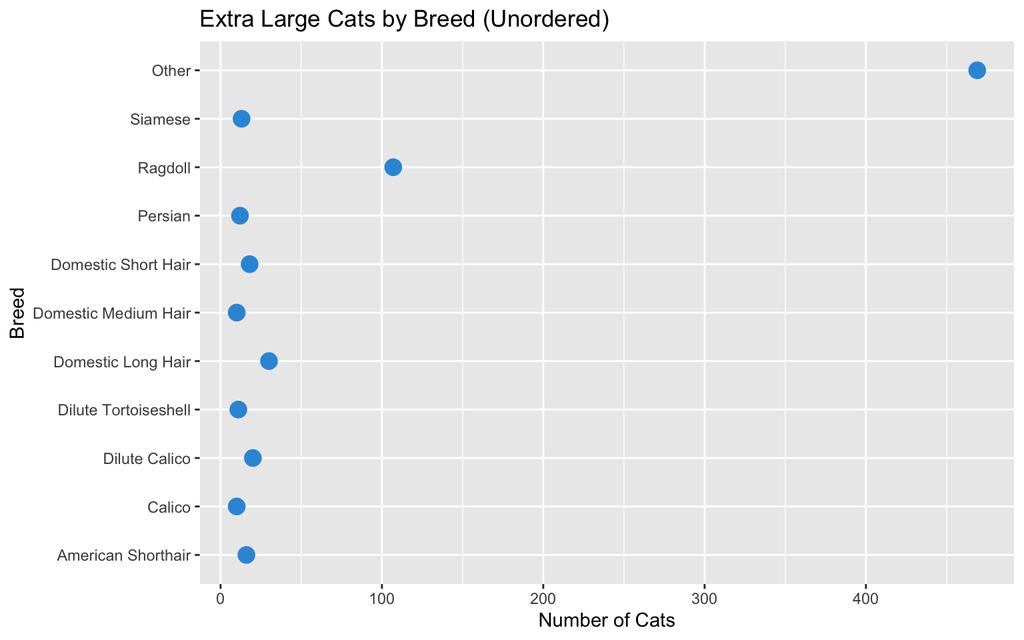

```r
# Filter for Extra Large cats
extra_large_cats <- cat_breeds |>
  filter(size == "Extra Large")

# Summarize the data by breed
extra_large_summary <- extra_large_cats |>
  group_by(breed) |>
  summarize(count = n())

# First plot (unordered)
ggplot(extra_large_summary, aes(x = count, y = breed)) +
  geom_point(color = "#3498db", size = 4) +
  labs(title = "Extra Large Cats by Breed (Unordered)",
       x = "Number of Cats",
       y = "Breed")
```

**💡 Click to see the Solution**

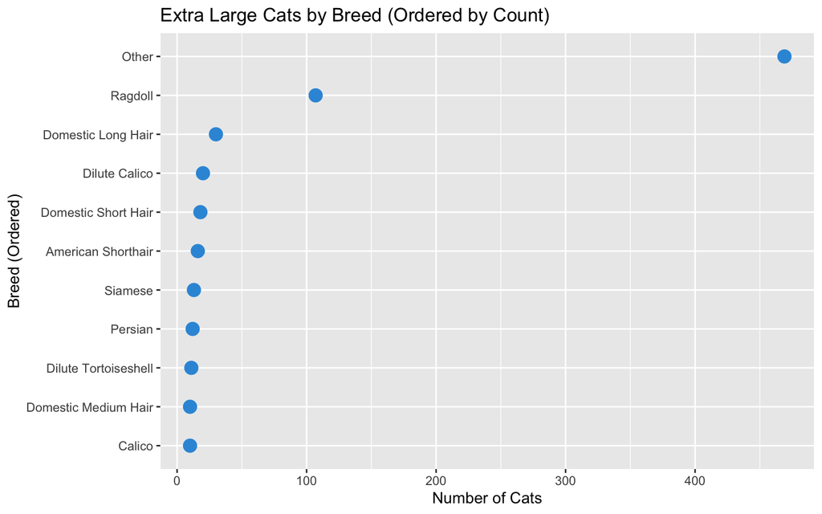

```r
# Second plot (ordered by count)
ggplot(extra_large_summary, aes(x = count, y = fct_reorder(breed, count))) +
  geom_point(color = "#3498db", size = 4) +
  labs(title = "Extra Large Cats by Breed (Ordered by Count)",
       x = "Number of Cats",
       y = "Breed (Ordered)")
```

**😈 See the Monster 😈**

[figure not shown]